# Mixture modelling in R

## Introduction

In this session we compute the mixture toxicity for two typical cases:

1. We have toxicity data from laboratory toxicity tests and want to predict the joint effect.
2. We have field data with chemical concentrations and want to predict a joint effect.

## 1. Computing mixture toxicity for lab test data with dose-response information

We will use data that comes with the R package `mixtox`. This contains toxicity information on the antibiotics neomycin sulfate (NEO), streptomycin sulfate (STR), kanamycin sulfate (KAN), spectinomycin dihydrochloridehydrate (SPE), paromomycin sulfate (PAR), dihydrostreptomycin sesquisulfate hydrate (DIH) and gentamycin sulfate (GEN).

```r
library(mixtox)
data(antibiotox)
```

You can access data for individual antibiotics using the acronym in the brackets above. For example, we express the data for PAR:

```r
antibiotox$PAR
```

```
## $x
##  [1] 1.718e-07 2.291e-07 3.551e-07 5.269e-07 7.789e-07 1.145e-06 1.718e-06
##  [8] 2.291e-06 3.551e-06 5.269e-06 7.789e-06 1.145e-05
##
## $y
##          tier1        tier2      tier3
## 3  -0.01907293 -0.023076476 0.02782089
## 4  -0.01770792  0.009446548 0.06065272
## 5   0.02687944  0.063064935 0.07175286
## 6   0.04713938  0.086031958 0.10548726
## 7   0.13895028  0.141419024 0.14888114
## 8   0.19878043  0.204747952 0.19074755
## 9   0.30712384  0.315195821 0.36082551
## 10  0.49816509  0.467559601 0.51365877
## 11  0.74254537  0.731641939 0.75497213
## 12  0.89264161  0.882151175 0.88362630
## 13  0.91703287  0.915215125 0.91532119
## 14  0.93887304  0.929476159 0.93460542
##
## $name
## [1] "PAR"
##
## $concNum
## [1] 12
##
## $tierNum
## [1] 3
##
## $type
## [1] "antibiotox"
```

In the output, *x* provides the concentrations in mol/L and *y* response information from effects on photobacteria in a microplate. Let us visualise the data. To do this, we first extract the concentration and response values into new objects.

```r
conc <- antibiotox$PAR$x
effect_par <- antibiotox$PAR$y
```

Subsequently, we use a function of the package to fit a dose-response model and then plot the result. For fitting, we have multiple options for model type and choose the Logit model, which we set with the argument `eq = 'Logit'`. Furthermore, we need to provide starting parameters for model fitting, with the argument `param` and a numeric vector for the calculation of effect concentrations such as the EC50, which would correspond to a value of 0.5. See the help of the function for further information.

```r
par_fit <- curveFit(x = conc, rspn = effect_par, eq ='Logit', param = c(26, 4), effv = c(0.05, 0.5))
```

```
##
## Processing quantal quantal dose-response data
```

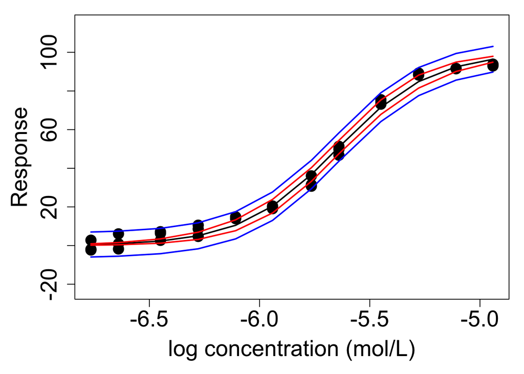

```r
# plot model
figPlot(par_fit, xlabel = "log concentration (mol/L)")
```

The figure shows the observations (black dots) with the fitted dose response curve (black line), the confidence interval (red line) and the prediction interval (blue line).

The effect concentrations are:

```r
par_fit$ecx
```

```
##               EC5         EC50
## Logit 5.24183e-07 2.247119e-06
```

The dataset object *antibiotox* already contains fitted curves for all compounds. We can use these to calculate different mixture toxicity models. *antibiotox$sgl* provides information on the fitted model type and the related parameters.

```r
antibiotox$sgl
```

```
## $model
## [1] "Logit"   "Weibull" "Weibull" "Weibull" "Logit"   "Weibull" "Weibull"
##
## $param
##     alpha beta gamma
## PAR 26.31 4.66     0
## SPE 12.44 2.36     0
## KAN 13.76 2.66     0
## STR 15.57 2.35     0
## DIH 19.72 2.99     0
## GEN 21.00 3.49     0
## NEO 17.18 2.87     0
```

```r
# for PAR the parameters are the same as in the object we just fitted
par_fit$fitInfo
```

```
##
## Formula: y ~ 1/(1 + exp((-Alpha) - Beta * log10(x)))
##
## Parameters:
##       Estimate Std. Error t value Pr(>|t|)
## Alpha  26.3094     1.4903   17.65 7.24e-09 ***
## Beta    4.6579     0.2632   17.69 7.08e-09 ***
## ---
## Signif. codes:  0 '***' 0.001 '**' 0.01 '*' 0.05 '.' 0.1 ' ' 1
##
## Residual standard error: 0.02897 on 10 degrees of freedom
##
## Number of iterations to convergence: 9
## Achieved convergence tolerance: 1.49e-08
```

We first calculate the predicted mixture for the Concentration Addition (CA) approach. The function `caPred()` has an argument `mixType`, where you need to provide the design of the mixture. This can be an arbitrary concentration ratio (*acr*), equal effect concentration ratio (*eecr*, e.g. all components at their EC10) or concentrations following the so-called uniform design concentration ratio, which is explained [here](https://journal.r-project.org/articles/RJ-2016-056/). Note the relationship of the *eecr* approach to the Toxic Unit (TU) approach. However, the eecr uses an effect benchmark to quantify a test concentration, whereas the TU approach standardizes a field concentration by an effect benchmark. We illustrate the prediction for the case of the equal effect concentration ratio, where all components are at their EC50. For this, you need to provide the model types and parameters for the individual chemicals as well as the design of the mixture as explained above. The argument `effv` provides the effect level for the equal effect concentration. We use the EC50, which translates into a value of 0.5, i.e. `effv = 0.5`. You could also provide multiple ECx values. Note that unless all dose-response curves exhibit the identical shape in terms of steepness, the mixture effects may vary with the effect level. The package has been designed to be compatible with the `drc` package that we used in the lecture on dose-response modelling. If you are interested in how to connect both packages, see the *Example 3* [here](https://journal.r-project.org/articles/RJ-2016-056/).

```r
# extract model type from the pre-fitted models
model <- antibiotox$sgl$model

# extract model parameters from the pre-fitted models
param <- antibiotox$sgl$param

# prediction with CA
eeca <- caPred(model, param, mixType = "eecr", effv = 0.5)

# inspect resulting object
eeca
```

```
## $ca
##                EC2.5          EC3          EC5         EC10         EC15
## ca.EE50 1.121884e-07 1.314756e-07 2.050312e-07 3.763211e-07 5.409417e-07
##                 EC20         EC25         EC30         EC35         EC40
## ca.EE50 7.049359e-07 8.716584e-07 1.043651e-06 1.223251e-06 1.412899e-06
##                 EC45         EC47         EC50         EC52         EC55
## ca.EE50 1.615383e-06 1.700702e-06 1.834087e-06 1.927036e-06 2.073331e-06
##                 EC60         EC65         EC70         EC75         EC80
## ca.EE50 2.338885e-06 2.638798e-06 2.984887e-06 3.395582e-06 3.902047e-06
##                 EC85         EC90
## ca.EE50 4.563355e-06 5.513748e-06
##
## $e
##  [1] 0.025 0.030 0.050 0.100 0.150 0.200 0.250 0.300 0.350 0.400 0.450 0.470
## [13] 0.500 0.520 0.550 0.600 0.650 0.700 0.750 0.800 0.850 0.900
##
## $pct
##            PAR       SPE       KAN        STR        DIH        GEN       NEO
## EC50 0.1760189 0.2917384 0.3808579 0.01288212 0.01977718 0.05878576 0.0599397
##
## $unitab
## NULL
```

The resulting object contains the predicted effect concentrations *ca* for the full dose-response curve when the components are at their EC50-ratios. These are given in the list *pct*.

We can also predict via the Independent Action (IA) model.

```r
# prediction with IA
eeia <- iaPred(model, param, mixType = "eecr", effv = c(0.5))

# inspect resulting object
eeia
```

```
## $ia
##               EC2.5          EC3          EC5         EC10         EC15
## ia.EE50 1.49386e-07 1.761326e-07 2.793586e-07 5.244684e-07 7.628608e-07
##                 EC20         EC25        EC30         EC35         EC40
## ia.EE50 1.001041e-06 1.242656e-06 1.49052e-06 1.747161e-06 2.015268e-06
##                 EC45         EC47         EC50         EC52         EC55
## ia.EE50 2.297755e-06 2.415541e-06 2.598197e-06 2.724338e-06 2.920997e-06
##                 EC60        EC65         EC70         EC75         EC80
## ia.EE50 3.272017e-06 3.65926e-06 4.094278e-06 4.594762e-06 5.189987e-06
##                 EC85         EC90
## ia.EE50 5.934438e-06 6.949172e-06
##
## $e
##  [1] 0.025 0.030 0.050 0.100 0.150 0.200 0.250 0.300 0.350 0.400 0.450 0.470
## [13] 0.500 0.520 0.550 0.600 0.650 0.700 0.750 0.800 0.850 0.900
##
## $pct
##            PAR       SPE       KAN        STR        DIH        GEN       NEO
## EC50 0.1760189 0.2917384 0.3808579 0.01288212 0.01977718 0.05878576 0.0599397
##
## $unitab
## NULL
```

The dataset also contains measurements of the mixture *antibiotox$ee50*, which we can confront with the data. A dose-response model has already been fitted and is provided (*antibiotox$eecr.mix*), which we use to calculate the EC50 with the function `ECx()`.

```r
mix_model <- antibiotox$eecr.mix$model[2]
mix_para <- antibiotox$eecr.mix$param[2, ]

# calculation of the EC50
# we wrap with the unname function to remove naming information
EC50_meas <- unname(ECx(mix_model, mix_para, effv = c(0.50)))
```

Let us finally compare the predictions to the empirical result in a plot.

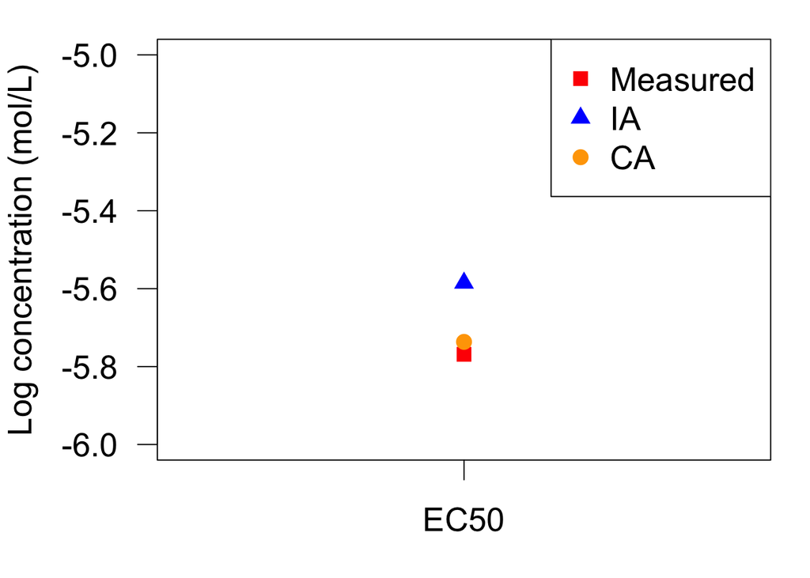

```r
par(mar = c(3, 4, 1, 1), cex = 1.7, las = 1)
# create vector with values
mix_vals <- log10(c(EC50_meas, eeia$ia[ , "EC50"], eeca$ca[ , "EC50"]))
# need (arbitrary) x values
x_vals <- rep(1,3)
plot(x_vals, mix_vals, xlim = c(0.75, 1.25),
    xaxt = "n", xlab = "", ylim = c(-6, -5),
     ylab = "Log concentration (mol/L)", col = c("red", "blue", "orange"), pch = c(15, 17, 19))
axis(1, at = 1, labels = "EC50")
# add legend
legend("topright", legend = c("Measured", "IA", "CA"), col = c("red", "blue", "orange"), pch = c(15, 17, 19))
```

The CA approach exhibits a better fit than IA. When we compute Model Deviation Ratios (MDRs), both MDRs are within the classical boundaries of 0.5 and 2.

```r
# MDR CA
eeca$ca[ , "EC50"]/EC50_meas
```

```
##          [,1]
## [1,] 1.076255
```

```r
# MDR IA
eeia$ia[ , "EC50"]/EC50_meas
```

```
##          [,1]
## [1,] 1.524641
```

**Now it is up to you**

1. Do the MDRs differ, when you calculate the mixture toxicity for the effect level EC5 for the equal effect concentration? Note that you also need to adjust the measured mixture effects accordingly.
2. Calculate mixture predictions for four heavy metals and four ionic liquids that are provided in the dataset *cytotox*. As for the other dataset, you find fitted dose-response curves for the individual chemicals in the sub list *cytotox$sgl* and for the measured mixture effects in *cytotox$eecr.mix*.

```r
data("cytotox")
?cytotox
```

## 2. Computing mixture toxicity for field data without associated toxicity data

We calculate the CA for one sampling site where 4 out of 10 target pesticides were detected. We also calculate the SSDs to derive the HC5 and the Response Addition (RA, equivalent to IA) model. This example is a strongly simplified version of a study comparing multiple exposure indicators. The original script for approximately hundred sampling sites and hundred of organic toxicants is available [here](http://pubs.acs.org/doi/suppl/10.1021/es4014954) and [here](http://tinyurl.com/ndqe8xx).

First we load and inspect the data. The Rdata object contains three objects: *MOA*, *field_dat* and *toxdat*. *MOA* contains information on the mode of action of the chemicals, which is required to decide on the null model. Similar and dissimilar MOAs suggest to use CA and IA, respectively. *field_dat* contains information on the results of the chemical analysis for the given sampling site. *toxdat* contains information on single species toxicity tests.

```r
load('Data.Rdata')

# Inspect data sets
# mode of action of compounds
head(MOA)
```

|  | Name | CAS | MOA | Target | MOAfinal |
| --- | --- | --- | --- | --- | --- |
| 1 | p,p -DDT | 50293 | Neurotoxicant DDT-type | sodium channel | Sodium channel |
| 2 | Trichlorfon | 52686 | Neurotoxicant (thio-)phosphate-type | Acetylcholine receptor | AChE Blocker |
| 3 | Parathion | 56382 | Neurotoxicant (thio-)phosphate-type | Acetylcholine receptor | AChE Blocker |
| 4 | g-hexachlorocyclohexane | 58899 | Neurotoxicant Cyclodiene-type | GABA antagonist | Sodium channel |
| 5 | Dimethoate | 60515 | Neurotoxicant (thio-)phosphate-type | Acetylcholine receptor | AChE Blocker |
| 6 | Dieldrin | 60571 | Neurotoxicant Cyclodiene-type | GABA antagonist | Sodium channel |

```r
# field observations
head(field_dat)
```

|  | Site | Date | CAS | operator | Conc | Source |
| --- | --- | --- | --- | --- | --- | --- |
| 888 | 2 | 26.5.2006 | 470906 | < | 0.02 | France |
| 889 | 2 | 26.5.2006 | 959988 | < | 0.02 | France |
| 890 | 2 | 26.5.2006 | 330552 | < | 0.02 | France |
| 891 | 2 | 26.5.2006 | 67306007 | < | 0.02 | France |
| 892 | 2 | 26.5.2006 | 19666309 | < | 0.02 | France |
| 893 | 2 | 26.5.2006 | 107534963 | < | 0.02 | France |

```r
# toxicity data
head(toxdat)
```

|  | PesticideName | TestCAS | TestDurationHours | TAXORDER | LATINNAME | ConcentrationUgLMedian | ReferenceNumber | Source |
| --- | --- | --- | --- | --- | --- | --- | --- | --- |
| 1553 | Carbofuran | 1563662 | 48 | Heteroptera | Anisops bouvieri | 1590.0 | 8303 | US EPA Ecotox |
| 1557 | Carbofuran | 1563662 | 96 | Haplotaxida | Branchiura sowerbyi | 7200.0 | 12536 | US EPA Ecotox |
| 1558 | Carbofuran | 1563662 | 96 | Decapoda | Caridina laevis | 950.0 | 100785 | US EPA Ecotox |
| 1560 | Carbofuran | 1563662 | 48 | Diplostraca | Ceriodaphnia dubia | 2.0 | 17097 | US EPA Ecotox |
| 1562 | Carbofuran | 1563662 | 48 | Diplostraca | Ceriodaphnia dubia | 2.6 | 13467 | US EPA Ecotox |
| 1563 | Carbofuran | 1563662 | 48 | Diptera | Chironomus riparius | 56.0 | 12280 | US EPA Ecotox |

We log transform the toxicity data, because we assume that a log normal model gives a reasonable fit for a SSD.

```r
toxdat$log_conc <- log10(toxdat$ConcentrationUgLMedian)
```

The data contains multiple results per combination of chemical and test organism.

```r
library(dplyr)
# Check for multiple compound-species combinations
toxdat %>%
  # Count occurrences per compound-species combination
  group_by(TestCAS, LATINNAME) %>%
  summarise(frequency = n(), .groups = "drop")
```

| TestCAS | LATINNAME | frequency |
| --- | --- | --- |
| 1563662 | Anisops bouvieri | 1 |
| 1563662 | Branchiura sowerbyi | 1 |
| 1563662 | Caridina laevis | 1 |
| 1563662 | Ceriodaphnia dubia | 2 |
| 1563662 | Chironomus riparius | 1 |
| 1563662 | Cyclops viridis | 1 |
| 1563662 | Cyprinotus carolinensis | 1 |
| 1563662 | Daphnia magna | 7 |
| 1563662 | Daphnia pulex | 1 |
| 1563662 | Echinogammarus tibaldii | 1 |

[output cut: 30 more lines]

We have several cases with multiple test results per pair of chemical - test organism. We create a new variable *comb_st* and then aggregate per pair of chemical - test organism using the mean. Note that we have log transformed the EC50, which means that we compute the geometric mean.

```r
toxdat <- toxdat %>%
  # Create compound-species combination
  mutate(comb_st = factor(paste0(TestCAS, ",", LATINNAME)))

tox_aggreg <- toxdat %>%
  group_by(comb_st) %>%
  # Calculate mean log EC50
  summarise(mean_logEC50 = mean(log_conc, na.rm = TRUE))

# We merge this with the original compound information
tox_aggreg_2   <-  tox_aggreg %>%
       inner_join(
       toxdat %>%
       distinct(TestCAS, PesticideName, LATINNAME, comb_st),
       by = join_by(comb_st)
      )
```

After this pre-processing, we can calculate Toxic Units (TU) for the different chemicals. We calculate the TUs for *Daphnia magna*, which is a frequently tested species considered representative for toxicity towards aquatic invertebrates.

```r
# Sub-setting to data for Daphnia magna
daph_tox <- tox_aggreg_2 %>%
            filter(LATINNAME == "Daphnia magna")

# Merge tox and field data, limited to concentration above the DL
TU_1 <- merge(daph_tox, field_dat[field_dat$operator == "=", ], by.x = "TestCAS", by.y = "CAS")

# Compute TU for each chemical in the given site
# Note that we need to consider the log-transformation
TU_1$ToxUnit  <- TU_1$Conc/ 10^TU_1$mean_logEC50

# Now we can calculate the sumTU assuming the concept of Concentration addition
sum(TU_1$ToxUnit)
```

```
## [1] 0.006932647
```

```r
# Typically expressed as log
log10(sum(TU_1$ToxUnit))
```

```
## [1] -2.159101
```

We obtain a sumTU of -2.16, which is above field-derived effect thresholds for invertebrate communities in streams (Liess et al. 2021 *Water Research* 201).

Next we calculate the sumTU for the HC5 of SSDs. This requires the calculation of SSDs as a first step. Note that the calculation of SSDs is only meaningful if multiple data points, i.e. tested species, are available. Let us check this.

```r
# Check for multiple compound-species combinations
tox_aggreg_2 %>%
  # Count occurrences per compound-species combination
  group_by(TestCAS, PesticideName) %>%
  summarise(frequency = n(), .groups = "drop")
```

| TestCAS | PesticideName | frequency |
| --- | --- | --- |
| 1563662 | Carbofuran | 24 |
| 15972608 | Alachlore | 14 |
| 23103982 | Pirimicarb | 1 |
| 34256821 | Acetochlor | 1 |

We have 24 and 14 different test species for carbofuran and alachlor, but only 1 for pirimicarb and acetochlor. Hence, we will limit the calculation of SSDs to the first two, using the condition of the related article, which required at least 6 different species for the calculation of a SSD.

```r
tox_filtered <- tox_aggreg_2 %>%
  semi_join(
    tox_aggreg_2 %>%
      group_by(TestCAS) %>%
      summarise(frequency = n(), .groups = "drop") %>%
      filter(frequency > 5),
    by = "TestCAS"
  )
```

We assume a log normal distribution of the data, which makes the computation quite convenient in the case of large data sets (this is not the case here, but the code was developed for > 100 compounds). In this case, the midpoint of the SSD, i.e. the HC50, is equivalent to the mean of the data. We calculate the midpoint for all compounds.

```r
tox_ssd_1 <- tox_aggreg_2 %>%
             group_by(TestCAS) %>%
             summarise(ssd_mid = mean(mean_logEC50), .groups = "drop")
```

To evaluate the slope of the dose-response relationship, we can use the standard deviation. A low and high standard deviation is related to a steep and shallow slope. Before the calculation of the standard deviation, we center the data by the mean. This allows us to interpret the slopes independently of the mean. It makes the slope represent the change in response per standard deviation, not just per unit of the original scale.

```r
mean_all <- mean(tox_filtered$mean_logEC50)
# center = subtract overall mean
tox_filtered$Center_logEC50 <- tox_filtered$mean_logEC50 - mean_all
```

Now we can compute the standard deviation for each compound-species combination where at least 6 data points are available.

```r
tox_ssd_2 <- tox_filtered %>%
             group_by(TestCAS) %>%
             summarise(ssd_slope = sd(Center_logEC50), .groups = "drop")
```

Obviously, we now lack two slopes. Let us check the MOAs of the compounds.

```r
MOA[MOA$CAS %in% tox_aggreg_2$TestCAS, ]
```

|  | Name | CAS | MOA | Target | MOAfinal |
| --- | --- | --- | --- | --- | --- |
| 43 | Carbofuran | 1563662 | Neurotoxicant Carbamate | Acetylcholine receptor | AChE Blocker |
| 53 | Alachlore | 15972608 | chloroacetanilide | NA | Narcosis |
| 58 | Pirimicarb | 23103982 | Neurotoxicant Carbamate | Acetylcholine receptor | AChE Blocker |
| 64 | Acetochlor | 34256821 | chloroacetanilide | NA | Narcosis |

We are lucky! The two missing slopes belong to compounds that have the same MOA as the compounds for which we have slopes. We assume that the slopes of the SSDs can be approximated from that of compound(s) with the same MOA. Hence, we fill the missing slope data accordingly.

```r
ssd_fin <- tox_ssd_1 %>%
  left_join(tox_ssd_2, by = "TestCAS")
ssd_fin
```

| TestCAS | ssd_mid | ssd_slope |
| --- | --- | --- |
| 1563662 | 2.501322 | 1.2104378 |
| 15972608 | 4.093377 | 0.3117868 |
| 23103982 | 1.211716 | NA |
| 34256821 | 3.913814 | NA |

```r
# replace NAs with slopes from compound with same MOA
ssd_fin$ssd_slope[3] <- ssd_fin$ssd_slope[1]
ssd_fin$ssd_slope[4] <- ssd_fin$ssd_slope[2]
```

We compute the HC5, which is the 5th percentile. We have assumed a log-normal distribution, therefore we can use a function to determine quantiles of the normal distribution using the log-transformed slope as input data.

```r
 ssd_fin  <-  ssd_fin %>%
              mutate(log_HC5 = ssd_mid + qnorm(0.05, mean = 0, sd = ssd_slope))
```

We now merge the data with the field data and can calculate the sumTU for the HC5.

```r
TU_2 <- merge(ssd_fin, field_dat[field_dat$operator == "=", ], by.x = "TestCAS", by.y = "CAS")

# calculate TU
TU_2 <- TU_2 %>%
     mutate(TU_HC5 = Conc / 10^log_HC5)

# calculate the sumTU
sum(TU_2$TU_HC5)
```

```
## [1] 0.297815
```

Thus, the field concentrations reach a level of roughly 30% of the HC5, assuming CA to aggregate the exposure to different compounds.

Finally, let us calculate the RA model. Admittedly, this is not particularly meaningful in this case of just a few compounds, but it serves the purpose of illustration. We compute the RA for the HC50, because this is a more robust proxy than the HC5. Thus, we start by calculating the TU_HC50.

```r
# calculate TU
TU_2 <- TU_2 %>%
     mutate(TU_HC50 = Conc / 10^ssd_mid)
```

Now we compute the sumTU per MOA. As a first step, we merge the MOA data with our dataset.

```r
# append MOA
TU_2 <- TU_2 %>%
  left_join(MOA, by = c("TestCAS" = "CAS"))
```

In the related study, we used highly aggregated MOAs, because we could only calculate SSDs for a very limited number of compounds. These aggregated MOAs are given by the variable *MOAfinal*. We use this to calculate the sumTU.

```r
TU_3 <- TU_2 %>%
             group_by(MOAfinal) %>%
             summarise(sumTU_HC50 = sum(TU_HC50), .groups = "drop")
```

The elegance of the SSD approach is that we can directly estimate a Potentially Affected Fraction (PAF). We compute the multi-substance PAF (msPAF) per MoA.

```r
# we add the SSD slope
TU_4  <-   TU_3 %>%
    left_join(
    TU_2 %>%
      select(MOAfinal, ssd_slope) %>%
      distinct(),
    by = "MOAfinal")

# now we use the pnorm function, which provides the cumulative probability,
# which in our case is equivalent to the msPAF

TU_4  <-  TU_4 %>%
              mutate(msPAF = pnorm(log10(sumTU_HC50), mean = 0, sd = ssd_slope))

##
TU_4
```

| MOAfinal | sumTU_HC50 | ssd_slope | msPAF |
| --- | --- | --- | --- |
| AChE Blocker | 3.040187e-03 | 1.2104378 | 1.878592e-02 |
| Narcosis | 1.123738e-05 | 0.3117868 | 4.788692e-57 |

Note that the narcotic substances have practically zero effect (the msPAF is quasi 0). As a final step, we compute the RA, where the formula is: $msPAF_{RA} = 1 - \prod_{i=1}^n msPAF_i$.

```r
msPAF_RA <- 1-((1-TU_4$msPAF[1])*(1-TU_4$msPAF[2]))
attr(msPAF_RA, "names") <- "msPAF_RA"
msPAF_RA
```

```
##   msPAF_RA
## 0.01878592
```

Thus, we estimate that approximately 2% of species would be affected.

**Now it is up to you**

Load the data for the Exercise *Exercise.RData*. The object contains new field data (*field_dat2*) and more comprehensive toxicity data (*tox_dat_4*). Use these data (together with the other files where needed) and compute the sumTU *Daphnia magna* for this site as well as the sumTU HC5. Also consider calculating the msPAF RA if you want to boost your skills. You could also calculate the TU for the most sensitive species, how would you do this?

**Advanced exercise** Instead of using the data set provided with the exercise, we can query data interactively. The R package `standartox` (Scharmueller et al. 2020 https://doi.org/10.3390/data5020046) provides standardised and quality-controlled toxicity data based on the EPA data set that we used above. We already used it in previous sessions and you can simply load the Rdata object that we saved. Alternatively download from the GitHub repo of this course and place it in the directory from which you loaded your RMarkdown file.

[output not shown]

[output not shown]

[output not shown]

[output not shown]

[output not shown]

[output not shown]

[output not shown]

[output not shown]

[output not shown]

[output not shown]

[output not shown]

[output not shown]

[output not shown]

[output not shown]

[output not shown]

[output not shown]

```
## Loading objects:
##   dat3
```

In case, you do not have the file, you can execute the code below. First, we load the package and download the latest version of the database. Make sure you have the package installed, if not, execute the related rows from the installation script of this course (note that standartox is not on CRAN, but on github and therefore also requires installation of the package `remotes`).

```r
library(standartox)

dat = stx_data()
tax = stx_taxa()
che = stx_chem()
# merge data sets
dat2 = merge(dat, tax, by = 'tl_id', all.x = TRUE)
dat3 = merge(dat2, che, by = 'cl_id', all.x = TRUE)
# pre-processing according to the github code
```

The standartox data contains all toxicity information for all organism groups, we generate a brief overview.

```r
table(dat3$tax_group)
```

```
##
##                        algae          algae || macrophyte
##                        32298                         1702
## algae || macrophyte || plant               algae || plant
##                         1193                        30295
##                     amphibia                         aves
##                        30719                        43348
##                         fish                        fungi
##                       327214                        27152
##          fungi || macrophyte                 invertebrate
##                           48                       384513
##                   macrophyte          macrophyte || plant
##                           26                        34145
##                     mammalia                        plant
##                        85678                       187867
##        plant || invertebrate                     reptilia
##                            3                         2550
```

```r
table(dat3$tax_habitat)
```

```
##
##                            brack                   brack || fresh
##                             2270                           162098
##          brack || fresh || terre                   brack || marin
##                            16109                            13258
##          brack || marin || fresh brack || marin || fresh || terre
##                           111035                            18029
##          brack || marin || terre                   brack || terre
##                              440                              628
##                            fresh                   fresh || terre
##                           249700                            83361
##                            marin                   marin || fresh
##                            49532                            16338
##          marin || fresh || terre                   marin || terre
##                             1680                             3621
##                            terre
##                           327487
```

We limit the data to freshwater invertebrates and choose mortality as effect and EC50 or LC50 as endpoint.

```r
dat4 <- subset(dat3, qualifier == "=" & tax_habitat == "fresh" &
             tax_group == "invertebrate" & effect == "mortality" &
             endpoint_group == "XX50")
```

Let us check the test duration.

```r
summary(dat4$duration)
```

```
##     Min.  1st Qu.   Median     Mean  3rd Qu.     Max.
## -9999.00    24.00    48.00    11.39    96.00  5110.00
```

We limit the test duration to 24 h to 120 h. Note that this requires justification in a real project; for example, one could verify the extent to which toxicity changes with duration and select a range with consistent toxicity levels.

```r
final_dat <- dat4 %>% filter(between(duration, 24, 120))
```

Now the data is ready for use, you can query information by CAS number, i.e. variable *casnr*. Note that you would need to justify each step in a scientific analysis, for the sake of this exercise we keep it brief. Be aware that taxonomic level and the units of concentrations may still vary in the data set.